# PESQUISA MERCADO INFORMAL EM FAVELAS NO RIO DE JANEIRO 2018

Fred Ramos

12 de fevereiro de 2019

#PREPARAÇÃO DOS DADOS ###Carregando o Banco de dados em SPSS

###Contando o número total de questionários na Base de Dados

| Número Total de Questionários |
| --- |
| 1141 |

###Contando o número total de questionários por bairros

| Bairros | Número de Questionários |
| --- | --- |
| Borel/Tijuca | 139 |
| Campinho/Cascadura | 100 |
| Grotão/Penha | 174 |
| Jacaré/Maria da Graça | 154 |
| Parque Acari/Acari | 110 |
| Vila Rica de Irajá/Acari | 52 |
| Pavão Pavãozinho/Copacabana | 136 |
| Tijuquinha/Itanhangá | 118 |
| Parque Royal/Portuguesa - Ilha | 150 |

###Tabulação cruzada entre questionários de Venda, Aluguel e Compra em 2017

|  | Comprou ou alugou em 2017 | Está vendendo em 2017 |
| --- | --- | --- |
| Sim, comprou em 2017 | 162 | 10 |
| Não | 5 | 222 |
| Sim, alugou em 2017 | 729 | 5 |

###Apresenta a localização dos questionarios

[interactive chart not shown]

Gerando um subconjunto de dados referentes a pesquisa de imóveis alugados em 2017

Gerando um subconjunto de dados referentes a pesquisa de imóveis comprados em 2017

Gerando um subconjunto de dados referentes a pesquisa de imoveis a venda em 2017

### Contando o número de entrevistados por gênero vend

|  | Masculino | Feminino |
| --- | --- | --- |
| Borel/Tijuca | 12 | 17 |
| Campinho/Cascadura | 2 | 16 |
| Grotão/Penha | 20 | 50 |
| Jacaré/Maria da Graça | 8 | 16 |
| Parque Acari/Acari | 8 | 20 |
| Vila Rica de Irajá/Acari | 3 | 6 |
| Pavão Pavãozinho/Copacabana | 12 | 4 |
| Tijuquinha/Itanhangá | 4 | 3 |
| Parque Royal/Portuguesa - Ilha | 15 | 21 |

###Ultimo local de moradia venda

|  | Nunca me mudei | Outra casa nesta comunidade | Outra comunidade no município do Rio de Janeiro. Comunidade? | Outra comunidade fora do município do Rio de Janeiro. Municí | Outro bairro no município do Rio de Janeiro que não era comu | Outro bairro fora do município do Rio de Janeiro que não era |
| --- | --- | --- | --- | --- | --- | --- |
| Borel/Tijuca | 7 | 9 | 2 | 0 | 6 | 5 |
| Campinho/Cascadura | 6 | 6 | 2 | 1 | 2 | 1 |
| Grotão/Penha | 33 | 20 | 6 | 1 | 10 | 0 |
| Jacaré/Maria da Graça | 5 | 12 | 4 | 0 | 3 | 0 |
| Parque Acari/Acari | 4 | 13 | 7 | 0 | 4 | 0 |
| Vila Rica de Irajá/Acari | 1 | 7 | 0 | 0 | 1 | 0 |
| Pavão Pavãozinho/Copacabana | 6 | 8 | 0 | 0 | 2 | 0 |
| Tijuquinha/Itanhangá | 0 | 1 | 3 | 0 | 3 | 0 |
| Parque Royal/Portuguesa - Ilha | 4 | 14 | 5 | 1 | 9 | 3 |

###aluguel por comodo

| NumComodos | Valor medio do aluguel |
| --- | --- |
| 1 | 404.5 |
| 2 | 422.9 |
| 3 | 475.4 |
| 4 | 542.4 |
| 5 | 583.3 |
| 6 | 595.1 |
| 7 | 571.5 |
| 8 | 762.5 |
| 9 | 450.0 |
| 10 | 925.0 |

###aluguel por comodo dormitorio

| NumComodos_dormitorios | Valor medio do aluguel |
| --- | --- |
| 1 | 490.7 |
| 2 | 596.9 |
| 3 | 576.0 |
| 4 | 600.0 |
| 5 | 1000.0 |

###valor aluguel por domitorio

| NumComodos_dormitorios | Valor medio do aluguel |
| --- | --- |
| Borel/Tijuca | 392.5 |
| Campinho/Cascadura | 352.1 |
| Grotão/Penha | 334.3 |
| Jacaré/Maria da Graça | 374.1 |
| Parque Acari/Acari | 333.8 |
| Vila Rica de Irajá/Acari | 357.6 |
| Pavão Pavãozinho/Copacabana | 523.8 |
| Tijuquinha/Itanhangá | 543.0 |
| Parque Royal/Portuguesa - Ilha | 441.9 |

###Valor compra por comodo dormitorio

| NumComodos_dormitorios | Valor compra (reais/dormitorio |
| --- | --- |
| Borel/Tijuca | 20766.7 |
| Campinho/Cascadura | 19471.4 |
| Grotão/Penha | 29666.7 |
| Jacaré/Maria da Graça | 23360.0 |
| Parque Acari/Acari | 23243.6 |
| Vila Rica de Irajá/Acari | 20694.4 |
| Pavão Pavãozinho/Copacabana | 29750.0 |
| Tijuquinha/Itanhangá | 65000.0 |
| Parque Royal/Portuguesa - Ilha | 31047.6 |

### Idade média por gênero

| Gênero | Média de Idade | Número de Casos |
| --- | --- | --- |
| Masculino | 35.6 | 474 |
| Feminino | 35.3 | 659 |

```
##        Q_15 Q_14 == 55.FALSE Q_14 == 55.TRUE
## 1 Masculino      0.987341772     0.012658228
## 2  Feminino      0.990895296     0.009104704
```

###Média de idade por situação conjugal

| Situação Conjugal | Média de Idade | Número de Casos |
| --- | --- | --- |
| Solteiro(a) | 33.4 | 501 |
| Casado(a) | 35.2 | 481 |
| União consensual | 33.6 | 88 |
| Separado (a) | 50.5 | 6 |
| Divorciado(a)/desquitado(a) | 51.1 | 32 |
| Viúvo(a) | 63.3 | 25 |

###Total de entrevistados por estado de origem

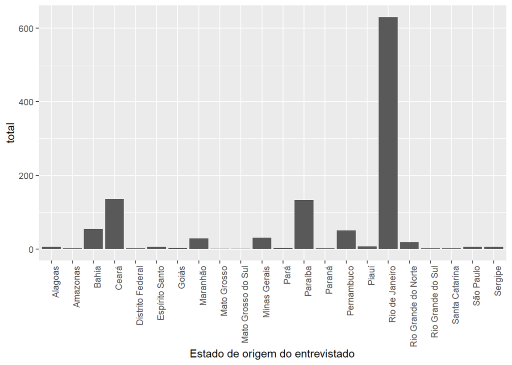

### Nível de escolaridade por Bairro

|  | Creche | Pré-escolar (maternal e jardim de infância) | Classe de alfabetização - ca | Alfabetização de jovens e adultos | Regular do ensino fundamental | Educação de jovens e adultos - eja - ou supletivo do ensino | Regular do ensino médio | Educação de jovens e adultos - eja - ou supletivo do ensino _duplicated_8 | Superior de graduação | Especialização de nível superior (mínimo de 360 horas) | Mestrado | Doutorado |
| --- | --- | --- | --- | --- | --- | --- | --- | --- | --- | --- | --- | --- |
| Borel/Tijuca | 1 | 1 | 3 | 17 | 50 | 0 | 57 | 2 | 6 | 0 | 1 | 1 |
| Campinho/Cascadura | 0 | 1 | 8 | 4 | 45 | 7 | 30 | 2 | 3 | 0 | 0 | 0 |
| Grotão/Penha | 1 | 5 | 10 | 23 | 63 | 16 | 49 | 2 | 3 | 2 | 0 | 0 |
| Jacaré/Maria da Graça | 2 | 2 | 3 | 25 | 38 | 9 | 58 | 12 | 5 | 0 | 0 | 0 |
| Parque Acari/Acari | 0 | 0 | 1 | 9 | 62 | 0 | 34 | 1 | 2 | 1 | 0 | 0 |
| Vila Rica de Irajá/Acari | 0 | 0 | 0 | 3 | 21 | 0 | 26 | 1 | 1 | 0 | 0 | 0 |
| Pavão Pavãozinho/Copacabana | 2 | 0 | 11 | 19 | 30 | 13 | 55 | 4 | 2 | 0 | 0 | 0 |
| Tijuquinha/Itanhangá | 0 | 1 | 4 | 13 | 35 | 1 | 58 | 0 | 6 | 0 | 0 | 0 |
| Parque Royal/Portuguesa - Ilha | 1 | 0 | 15 | 19 | 48 | 6 | 59 | 2 | 0 | 0 | 0 | 0 |

###Quantos trabalhos possui

|  | Um | Dois ou mais | Não trabalha |
| --- | --- | --- | --- |
| Borel/Tijuca | 91 | 9 | 39 |
| Campinho/Cascadura | 54 | 4 | 42 |
| Grotão/Penha | 103 | 0 | 71 |
| Jacaré/Maria da Graça | 96 | 7 | 51 |
| Parque Acari/Acari | 51 | 2 | 57 |
| Vila Rica de Irajá/Acari | 23 | 1 | 28 |
| Pavão Pavãozinho/Copacabana | 108 | 0 | 28 |
| Tijuquinha/Itanhangá | 85 | 7 | 26 |
| Parque Royal/Portuguesa - Ilha | 88 | 8 | 54 |

###Qual o tipo de trabalho exerce

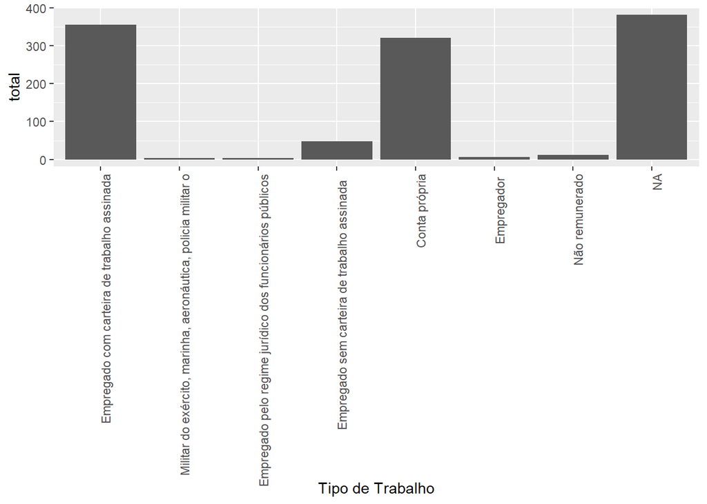

###Em qual setor trabalha

|  | Comércio | Serviço | Indústria | Construção civil | Outros |
| --- | --- | --- | --- | --- | --- |
| Borel/Tijuca | 38 | 50 | 2 | 5 | 5 |
| Campinho/Cascadura | 25 | 26 | 1 | 4 | 2 |
| Grotão/Penha | 39 | 55 | 5 | 4 | 0 |
| Jacaré/Maria da Graça | 56 | 31 | 8 | 6 | 8 |
| Parque Acari/Acari | 28 | 19 | 2 | 3 | 9 |
| Vila Rica de Irajá/Acari | 17 | 6 | 1 | 0 | 0 |
| Pavão Pavãozinho/Copacabana | 49 | 55 | 1 | 2 | 1 |
| Tijuquinha/Itanhangá | 45 | 36 | 2 | 7 | 2 |
| Parque Royal/Portuguesa - Ilha | 30 | 50 | 2 | 11 | 3 |

###Onde se localiza o trabalho

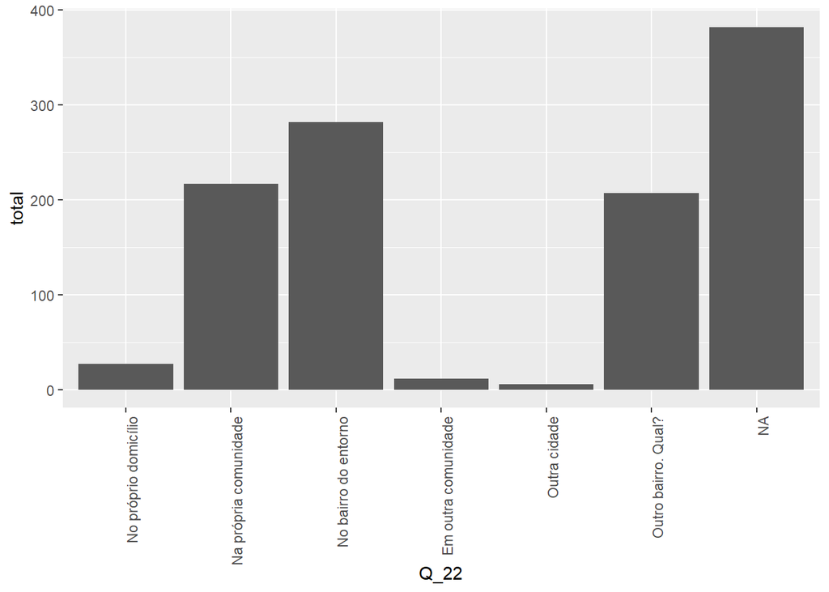

###Onde se localiza o trabalho

|  | No próprio domicílio | Na própria comunidade | No bairro do entorno | Em outra comunidade | Outra cidade | Outro bairro. Qual? |
| --- | --- | --- | --- | --- | --- | --- |
| Borel/Tijuca | 2 | 35 | 20 | 1 | 0 | 42 |
| Campinho/Cascadura | 6 | 13 | 14 | 2 | 0 | 23 |
| Grotão/Penha | 0 | 27 | 61 | 2 | 2 | 11 |
| Jacaré/Maria da Graça | 11 | 34 | 21 | 1 | 2 | 40 |
| Parque Acari/Acari | 2 | 27 | 14 | 1 | 1 | 16 |
| Vila Rica de Irajá/Acari | 1 | 11 | 8 | 0 | 0 | 4 |
| Pavão Pavãozinho/Copacabana | 2 | 26 | 49 | 1 | 0 | 30 |
| Tijuquinha/Itanhangá | 1 | 27 | 35 | 2 | 1 | 26 |
| Parque Royal/Portuguesa - Ilha | 2 | 17 | 60 | 2 | 0 | 15 |

### Renda pessoal mensal compradores

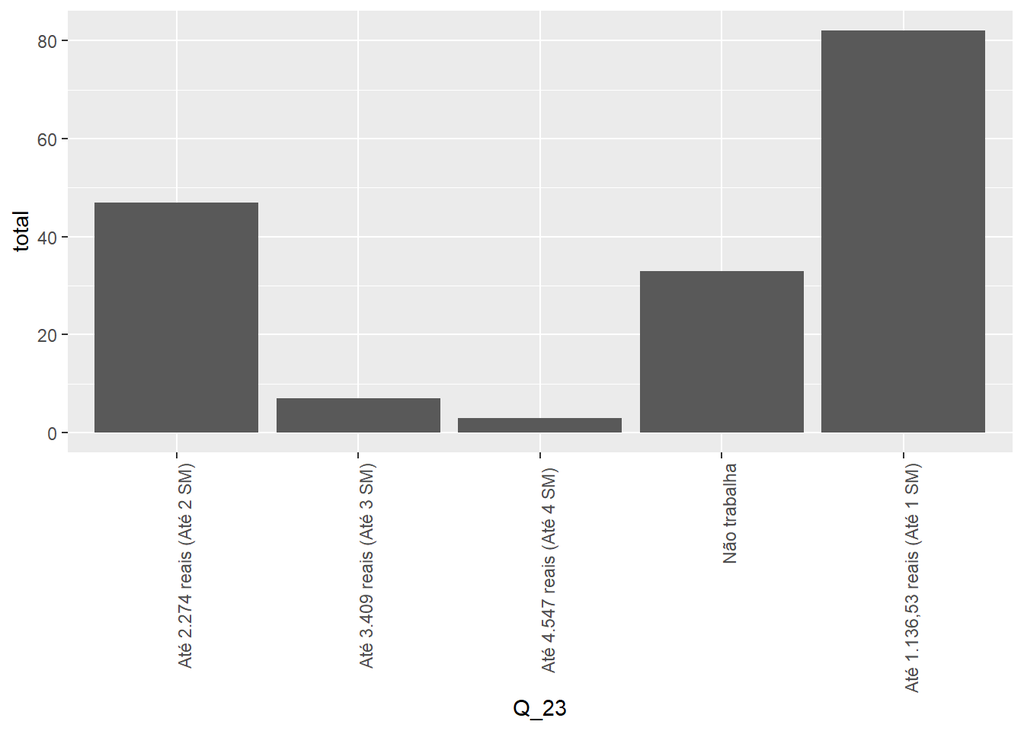

### Renda pessoal por comunidade

|  | Até 2.274 reais (Até 2 SM) | Até 3.409 reais (Até 3 SM) | Até 4.547 reais (Até 4 SM) | Até 5.683 reais (Até 5 SM) | Até 6.820 reais (Até 6 SM) | Até 7.956 reais (Até 7 SM) | Até 9.093 reais (Até 8 SM) | Até 10.229 reais (Até 9 SM) | Até 11.366 reais (Até 10 SM) | Até 17.047 reais (Até 15 SM) | Até 22.730 reais (Até 20 SM) | Mais de 22.730 reais (Mais de 20 SM) | Não sabe/Não respondeu | Não trabalha | Até 1.136,53 reais (Até 1 SM) |
| --- | --- | --- | --- | --- | --- | --- | --- | --- | --- | --- | --- | --- | --- | --- | --- |
| Borel/Tijuca | 16 | 2 | 0 | 0 | 0 | 0 | 0 | 0 | 0 | 0 | 0 | 0 | 0 | 6 | 12 |
| Campinho/Cascadura | 5 | 0 | 1 | 0 | 0 | 0 | 0 | 0 | 0 | 0 | 0 | 0 | 0 | 4 | 8 |
| Grotão/Penha | 1 | 1 | 0 | 0 | 0 | 0 | 0 | 0 | 0 | 0 | 0 | 0 | 0 | 6 | 16 |
| Jacaré/Maria da Graça | 8 | 1 | 0 | 0 | 0 | 0 | 0 | 0 | 0 | 0 | 0 | 0 | 0 | 3 | 12 |
| Parque Acari/Acari | 1 | 0 | 0 | 0 | 0 | 0 | 0 | 0 | 0 | 0 | 0 | 0 | 0 | 4 | 10 |
| Vila Rica de Irajá/Acari | 1 | 0 | 0 | 0 | 0 | 0 | 0 | 0 | 0 | 0 | 0 | 0 | 0 | 2 | 3 |
| Pavão Pavãozinho/Copacabana | 6 | 1 | 1 | 0 | 0 | 0 | 0 | 0 | 0 | 0 | 0 | 0 | 0 | 4 | 6 |
| Tijuquinha/Itanhangá | 5 | 2 | 1 | 0 | 0 | 0 | 0 | 0 | 0 | 0 | 0 | 0 | 0 | 2 | 5 |
| Parque Royal/Portuguesa - Ilha | 4 | 0 | 0 | 0 | 0 | 0 | 0 | 0 | 0 | 0 | 0 | 0 | 0 | 2 | 10 |

### Quantas pessoas contribuem para a renda

|  | 0 | 1 | 2 | 3 | 4 | 5 | 6 | 10 |
| --- | --- | --- | --- | --- | --- | --- | --- | --- |
| Borel/Tijuca | 2 | 66 | 65 | 6 | 0 | 0 | 0 | 0 |
| Campinho/Cascadura | 0 | 63 | 31 | 4 | 0 | 0 | 2 | 0 |
| Grotão/Penha | 1 | 96 | 67 | 7 | 2 | 1 | 0 | 0 |
| Jacaré/Maria da Graça | 7 | 78 | 53 | 11 | 4 | 1 | 0 | 0 |
| Parque Acari/Acari | 3 | 77 | 19 | 9 | 1 | 1 | 0 | 0 |
| Vila Rica de Irajá/Acari | 2 | 33 | 16 | 1 | 0 | 0 | 0 | 0 |
| Pavão Pavãozinho/Copacabana | 4 | 68 | 47 | 15 | 2 | 0 | 0 | 0 |
| Tijuquinha/Itanhangá | 0 | 56 | 48 | 12 | 1 | 0 | 1 | 0 |
| Parque Royal/Portuguesa - Ilha | 1 | 84 | 59 | 2 | 2 | 1 | 0 | 1 |

### Qual sua renda familiar mensal

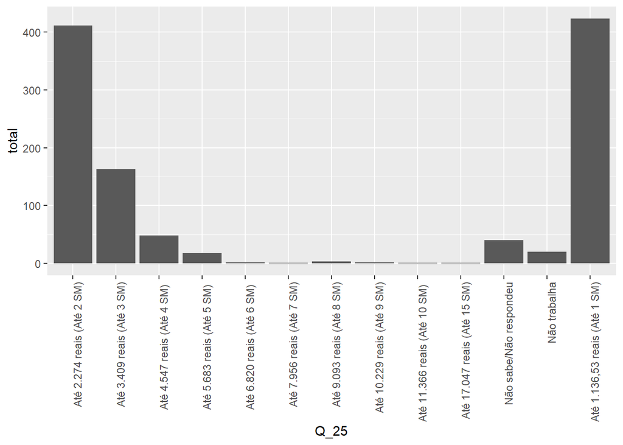

### Renda familiar por comunidade locatarios

|  | Até 2.274 reais (Até 2 SM) | Até 3.409 reais (Até 3 SM) | Até 4.547 reais (Até 4 SM) | Até 5.683 reais (Até 5 SM) | Até 6.820 reais (Até 6 SM) | Até 7.956 reais (Até 7 SM) | Até 9.093 reais (Até 8 SM) | Até 10.229 reais (Até 9 SM) | Até 11.366 reais (Até 10 SM) | Até 17.047 reais (Até 15 SM) | Até 22.730 reais (Até 20 SM) | Mais de 22.730 reais (Mais de 20 SM) | Não sabe/Não respondeu | Não trabalha | Até 1.136,53 reais (Até 1 SM) |
| --- | --- | --- | --- | --- | --- | --- | --- | --- | --- | --- | --- | --- | --- | --- | --- |
| Borel/Tijuca | 25 | 15 | 8 | 1 | 0 | 0 | 0 | 0 | 0 | 0 | 0 | 0 | 4 | 1 | 22 |
| Campinho/Cascadura | 23 | 8 | 2 | 0 | 0 | 0 | 0 | 0 | 0 | 0 | 0 | 0 | 11 | 1 | 20 |
| Grotão/Penha | 29 | 8 | 0 | 0 | 0 | 0 | 0 | 0 | 0 | 0 | 0 | 0 | 1 | 1 | 40 |
| Jacaré/Maria da Graça | 38 | 8 | 3 | 0 | 0 | 0 | 0 | 1 | 0 | 0 | 0 | 0 | 3 | 5 | 51 |
| Parque Acari/Acari | 19 | 5 | 0 | 2 | 0 | 0 | 2 | 0 | 0 | 0 | 0 | 0 | 3 | 0 | 36 |
| Vila Rica de Irajá/Acari | 10 | 3 | 2 | 0 | 0 | 0 | 0 | 0 | 0 | 0 | 0 | 0 | 3 | 1 | 18 |
| Pavão Pavãozinho/Copacabana | 38 | 18 | 5 | 0 | 0 | 0 | 0 | 0 | 0 | 0 | 0 | 0 | 3 | 3 | 35 |
| Tijuquinha/Itanhangá | 43 | 19 | 11 | 6 | 0 | 1 | 1 | 0 | 1 | 1 | 0 | 0 | 3 | 0 | 12 |
| Parque Royal/Portuguesa - Ilha | 41 | 15 | 1 | 0 | 0 | 0 | 0 | 0 | 0 | 0 | 0 | 0 | 3 | 0 | 41 |

### fomra de ocupação do domicilio

|  | Comprou o lote | Ocupou o lote | Comprou a casa | Ocupou a casa | Comprou a laje | Comprou habitação precária (barraco, palafita,etc..) | Doação | Herança | Troca | Reassentamento |
| --- | --- | --- | --- | --- | --- | --- | --- | --- | --- | --- |
| Borel/Tijuca | 3 | 1 | 13 | 1 | 2 | 1 | 0 | 6 | 0 | 0 |
| Campinho/Cascadura | 3 | 1 | 7 | 1 | 1 | 0 | 1 | 3 | 1 | 0 |
| Grotão/Penha | 14 | 0 | 52 | 0 | 0 | 1 | 1 | 1 | 1 | 0 |
| Jacaré/Maria da Graça | 1 | 0 | 18 | 0 | 0 | 0 | 1 | 3 | 0 | 0 |
| Parque Acari/Acari | 2 | 0 | 21 | 0 | 0 | 0 | 2 | 2 | 1 | 0 |
| Vila Rica de Irajá/Acari | 3 | 0 | 5 | 0 | 0 | 0 | 1 | 0 | 0 | 0 |
| Pavão Pavãozinho/Copacabana | 5 | 1 | 9 | 0 | 0 | 0 | 0 | 1 | 0 | 0 |
| Tijuquinha/Itanhangá | 2 | 0 | 3 | 0 | 0 | 0 | 0 | 0 | 0 | 0 |
| Parque Royal/Portuguesa - Ilha | 3 | 1 | 25 | 1 | 5 | 0 | 0 | 0 | 0 | 0 |

### Numero de pessoas por domicilio

| Bairro | Média de pessoas por domicilio | Desvio Padrão |
| --- | --- | --- |
| Borel/Tijuca | 3.1 | 1.3 |
| Campinho/Cascadura | 3.1 | 1.4 |
| Grotão/Penha | 3.3 | 1.7 |
| Jacaré/Maria da Graça | 3.1 | 1.3 |
| Parque Acari/Acari | 3.6 | 1.9 |
| Vila Rica de Irajá/Acari | 3.1 | 1.3 |
| Pavão Pavãozinho/Copacabana | 3.0 | 1.3 |
| Tijuquinha/Itanhangá | 2.8 | 1.1 |
| Parque Royal/Portuguesa - Ilha | 3.0 | 1.7 |

### Tipo de imovel

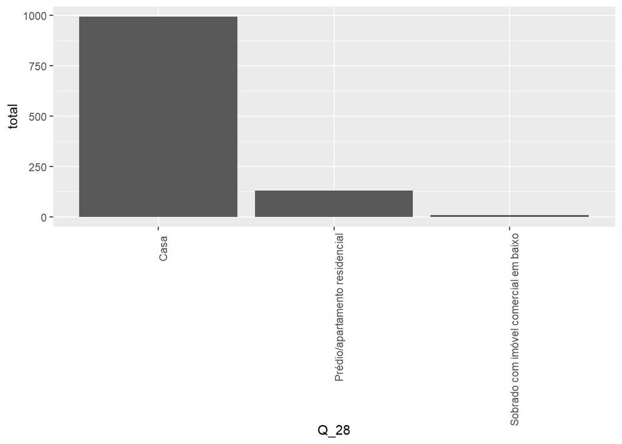

### Tipo de imovel por comunidade

|  | Casa | Prédio/apartamento residencial | Sobrado com imóvel comercial em baixo |
| --- | --- | --- | --- |
| Borel/Tijuca | 137 | 1 | 1 |
| Campinho/Cascadura | 99 | 1 | 0 |
| Grotão/Penha | 174 | 0 | 0 |
| Jacaré/Maria da Graça | 135 | 18 | 1 |
| Parque Acari/Acari | 104 | 6 | 0 |
| Vila Rica de Irajá/Acari | 45 | 6 | 1 |
| Pavão Pavãozinho/Copacabana | 136 | 0 | 0 |
| Tijuquinha/Itanhangá | 31 | 87 | 0 |
| Parque Royal/Portuguesa - Ilha | 133 | 12 | 5 |

### Uso do domiciclio

|  | Apenas residencial | Uso residencial com atividade econômica | Uso residencial e outro uso. Qual? |
| --- | --- | --- | --- |
| Borel/Tijuca | 136 | 3 | 0 |
| Campinho/Cascadura | 96 | 4 | 0 |
| Grotão/Penha | 174 | 0 | 0 |
| Jacaré/Maria da Graça | 149 | 5 | 0 |
| Parque Acari/Acari | 110 | 0 | 0 |
| Vila Rica de Irajá/Acari | 50 | 2 | 0 |
| Pavão Pavãozinho/Copacabana | 134 | 2 | 0 |
| Tijuquinha/Itanhangá | 117 | 1 | 0 |
| Parque Royal/Portuguesa - Ilha | 150 | 0 | 0 |

### Numero de pavimentos

|  | 1 pavimento | 2 pavimentos | 3 pavimentos | Mais de 3 pavimentos |
| --- | --- | --- | --- | --- |
| Borel/Tijuca | 86 | 29 | 8 | 16 |
| Campinho/Cascadura | 50 | 21 | 15 | 14 |
| Grotão/Penha | 93 | 76 | 5 | 0 |
| Jacaré/Maria da Graça | 101 | 27 | 20 | 6 |
| Parque Acari/Acari | 78 | 27 | 4 | 1 |
| Vila Rica de Irajá/Acari | 35 | 8 | 8 | 1 |
| Pavão Pavãozinho/Copacabana | 67 | 37 | 24 | 8 |
| Tijuquinha/Itanhangá | 79 | 6 | 11 | 22 |
| Parque Royal/Portuguesa - Ilha | 91 | 29 | 22 | 8 |

### Material do piso

|  | Terra | Tábua | Cimentado | Ladrilho | Taco | Carpete |
| --- | --- | --- | --- | --- | --- | --- |
| Borel/Tijuca | 1 | 0 | 21 | 117 | 0 | 0 |
| Campinho/Cascadura | 1 | 1 | 16 | 81 | 1 | 0 |
| Grotão/Penha | 0 | 1 | 65 | 107 | 1 | 0 |
| Jacaré/Maria da Graça | 0 | 0 | 44 | 110 | 0 | 0 |
| Parque Acari/Acari | 0 | 0 | 8 | 101 | 1 | 0 |
| Vila Rica de Irajá/Acari | 0 | 0 | 2 | 50 | 0 | 0 |
| Pavão Pavãozinho/Copacabana | 0 | 0 | 47 | 88 | 1 | 0 |
| Tijuquinha/Itanhangá | 1 | 0 | 1 | 116 | 0 | 0 |
| Parque Royal/Portuguesa - Ilha | 0 | 0 | 13 | 135 | 2 | 0 |

### Tem laje?

|  | Sim | Não |
| --- | --- | --- |
| Borel/Tijuca | 80 | 59 |
| Campinho/Cascadura | 69 | 31 |
| Grotão/Penha | 122 | 52 |
| Jacaré/Maria da Graça | 90 | 64 |
| Parque Acari/Acari | 73 | 37 |
| Vila Rica de Irajá/Acari | 34 | 18 |
| Pavão Pavãozinho/Copacabana | 80 | 56 |
| Tijuquinha/Itanhangá | 93 | 25 |
| Parque Royal/Portuguesa - Ilha | 111 | 39 |

### Fachada?

|  | Alvenaria sem revestimento | Alvenaria com chapisco | Alvenaria com revestimento completo, mas sem pintura | Alvenaria com revestimento completo, com pintura | Madeira aproveitada | Madeira apropriada para a construção (aparelhada) | Ladrilho |
| --- | --- | --- | --- | --- | --- | --- | --- |
| Borel/Tijuca | 20 | 34 | 17 | 65 | 0 | 0 | 3 |
| Campinho/Cascadura | 7 | 20 | 20 | 51 | 0 | 0 | 2 |
| Grotão/Penha | 11 | 48 | 57 | 58 | 0 | 0 | 0 |
| Jacaré/Maria da Graça | 25 | 33 | 23 | 68 | 1 | 0 | 4 |
| Parque Acari/Acari | 9 | 9 | 24 | 60 | 0 | 0 | 8 |
| Vila Rica de Irajá/Acari | 4 | 6 | 10 | 27 | 0 | 0 | 5 |
| Pavão Pavãozinho/Copacabana | 14 | 44 | 12 | 63 | 0 | 0 | 3 |
| Tijuquinha/Itanhangá | 1 | 9 | 10 | 83 | 0 | 0 | 15 |
| Parque Royal/Portuguesa - Ilha | 27 | 33 | 16 | 60 | 1 | 0 | 13 |

### Fachada

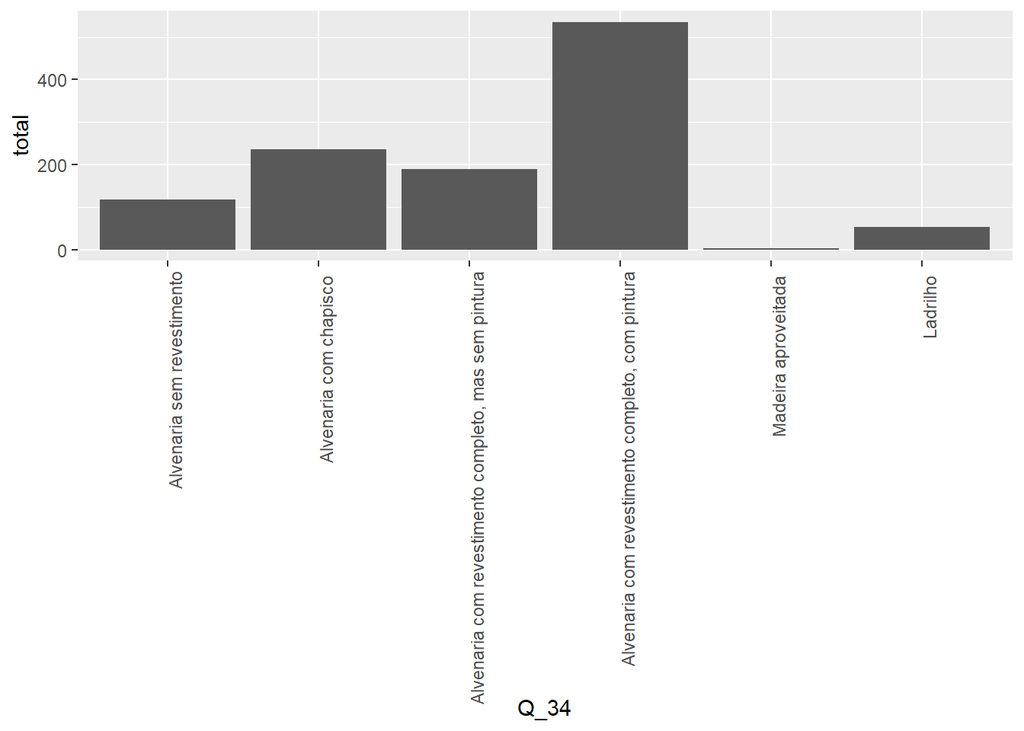

### Comodos por domicilio

|  | 1 | 2 | 3 | 4 | 5 | 6 | 7 | 8 | 9 | 10 | 11 | 12 |
| --- | --- | --- | --- | --- | --- | --- | --- | --- | --- | --- | --- | --- |
| Borel/Tijuca | 2 | 8 | 29 | 43 | 29 | 19 | 6 | 1 | 0 | 2 | 0 | 0 |
| Campinho/Cascadura | 0 | 4 | 18 | 40 | 25 | 6 | 4 | 0 | 1 | 1 | 1 | 0 |
| Grotão/Penha | 2 | 3 | 31 | 59 | 44 | 24 | 7 | 1 | 2 | 1 | 0 | 0 |
| Jacaré/Maria da Graça | 0 | 6 | 29 | 50 | 47 | 13 | 3 | 4 | 1 | 1 | 0 | 0 |
| Parque Acari/Acari | 1 | 4 | 21 | 35 | 29 | 15 | 3 | 1 | 0 | 0 | 0 | 1 |
| Vila Rica de Irajá/Acari | 0 | 5 | 10 | 16 | 13 | 7 | 1 | 0 | 0 | 0 | 0 | 0 |
| Pavão Pavãozinho/Copacabana | 0 | 10 | 35 | 53 | 28 | 7 | 2 | 1 | 0 | 0 | 0 | 0 |
| Tijuquinha/Itanhangá | 2 | 7 | 27 | 55 | 22 | 2 | 1 | 2 | 0 | 0 | 0 | 0 |
| Parque Royal/Portuguesa - Ilha | 1 | 28 | 41 | 44 | 22 | 8 | 2 | 4 | 0 | 0 | 0 | 0 |

### Média de Comodos

| Bairro | Média de cômodos por domicilio | Desvio Padrão | Média de dormitórios por domicilio | Desvio Padrão |
| --- | --- | --- | --- | --- |
| Borel/Tijuca | 4.4 | 1.5 | 1.6 | 0.7 |
| Campinho/Cascadura | 4.4 | 1.5 | 1.6 | 0.8 |
| Grotão/Penha | 4.5 | 1.4 | 1.6 | 0.6 |
| Jacaré/Maria da Graça | 4.4 | 1.3 | 1.6 | 0.7 |
| Parque Acari/Acari | 4.4 | 1.4 | 1.7 | 0.8 |
| Vila Rica de Irajá/Acari | 4.2 | 1.2 | 1.5 | 0.7 |
| Pavão Pavãozinho/Copacabana | 4.0 | 1.1 | 1.4 | 0.6 |
| Tijuquinha/Itanhangá | 3.9 | 1.1 | 1.4 | 0.5 |
| Parque Royal/Portuguesa - Ilha | 3.7 | 1.4 | 1.4 | 0.7 |

### Média de janelas por domicilio

| Bairro | Média de janelas por domicilio | Desvio Padrão | Média de janelas livres por domicilio | Desvio Padrão |
| --- | --- | --- | --- | --- |
| Borel/Tijuca | 2.9 | 1.4 | 2.3 | 1.6 |
| Campinho/Cascadura | 2.9 | 1.3 | 2.3 | 1.3 |
| Grotão/Penha | 3.0 | 1.5 | 2.1 | 1.5 |
| Jacaré/Maria da Graça | 2.7 | 1.4 | 2.0 | 1.5 |
| Parque Acari/Acari | 2.6 | 1.4 | 2.0 | 1.5 |
| Vila Rica de Irajá/Acari | 2.7 | 1.4 | 2.0 | 1.2 |
| Pavão Pavãozinho/Copacabana | 2.7 | 1.1 | 2.4 | 1.1 |
| Tijuquinha/Itanhangá | 2.6 | 1.3 | 1.7 | 1.3 |
| Parque Royal/Portuguesa - Ilha | 2.1 | 1.2 | 1.5 | 1.1 |

###Tem banheiro?

|  | Sim | Não |
| --- | --- | --- |
| Borel/Tijuca | 139 | 0 |
| Campinho/Cascadura | 100 | 0 |
| Grotão/Penha | 174 | 0 |
| Jacaré/Maria da Graça | 154 | 0 |
| Parque Acari/Acari | 110 | 0 |
| Vila Rica de Irajá/Acari | 52 | 0 |
| Pavão Pavãozinho/Copacabana | 136 | 0 |
| Tijuquinha/Itanhangá | 118 | 0 |
| Parque Royal/Portuguesa - Ilha | 150 | 0 |

###Banheiro coletivo?

|  | Só do domicílio | Comum a mais de um domicílio |
| --- | --- | --- |
| Borel/Tijuca | 139 | 0 |
| Campinho/Cascadura | 100 | 0 |
| Grotão/Penha | 174 | 0 |
| Jacaré/Maria da Graça | 153 | 1 |
| Parque Acari/Acari | 110 | 0 |
| Vila Rica de Irajá/Acari | 52 | 0 |
| Pavão Pavãozinho/Copacabana | 135 | 1 |
| Tijuquinha/Itanhangá | 118 | 0 |
| Parque Royal/Portuguesa - Ilha | 150 | 0 |

###Topologia do lote

|  | Plano | Plano em área de risco | Inclinado | Inclinado em área de risco |
| --- | --- | --- | --- | --- |
| Borel/Tijuca | 106 | 0 | 33 | 0 |
| Campinho/Cascadura | 73 | 3 | 21 | 3 |
| Grotão/Penha | 116 | 35 | 18 | 5 |
| Jacaré/Maria da Graça | 118 | 10 | 15 | 11 |
| Parque Acari/Acari | 108 | 1 | 1 | 0 |
| Vila Rica de Irajá/Acari | 51 | 1 | 0 | 0 |
| Pavão Pavãozinho/Copacabana | 94 | 5 | 36 | 1 |
| Tijuquinha/Itanhangá | 112 | 1 | 5 | 0 |
| Parque Royal/Portuguesa - Ilha | 145 | 4 | 1 | 0 |

### Tipo de logradouro

|  | Rua | Beco | Viela | Escadaria | Travessa | Avenida | Caminho | Ladeira | Passagem |
| --- | --- | --- | --- | --- | --- | --- | --- | --- | --- |
| Borel/Tijuca | 42 | 46 | 5 | 7 | 28 | 2 | 1 | 8 | 0 |
| Campinho/Cascadura | 70 | 9 | 4 | 5 | 4 | 1 | 4 | 3 | 0 |
| Grotão/Penha | 127 | 27 | 5 | 3 | 11 | 0 | 0 | 1 | 0 |
| Jacaré/Maria da Graça | 100 | 41 | 3 | 0 | 6 | 1 | 0 | 2 | 1 |
| Parque Acari/Acari | 71 | 23 | 0 | 0 | 12 | 4 | 0 | 0 | 0 |
| Vila Rica de Irajá/Acari | 34 | 8 | 1 | 0 | 8 | 0 | 0 | 1 | 0 |
| Pavão Pavãozinho/Copacabana | 62 | 49 | 4 | 12 | 4 | 3 | 1 | 0 | 1 |
| Tijuquinha/Itanhangá | 98 | 12 | 0 | 0 | 7 | 1 | 0 | 0 | 0 |
| Parque Royal/Portuguesa - Ilha | 80 | 40 | 2 | 0 | 12 | 16 | 0 | 0 | 0 |

###Mais de uma familia no domicilio?

|  | Sim | Não |
| --- | --- | --- |
| Borel/Tijuca | 5 | 134 |
| Campinho/Cascadura | 4 | 96 |
| Grotão/Penha | 4 | 170 |
| Jacaré/Maria da Graça | 9 | 145 |
| Parque Acari/Acari | 4 | 106 |
| Vila Rica de Irajá/Acari | 0 | 52 |
| Pavão Pavãozinho/Copacabana | 61 | 75 |
| Tijuquinha/Itanhangá | 2 | 116 |
| Parque Royal/Portuguesa - Ilha | 36 | 114 |

###Numero de familias por domicilio por bairros

|  |  | 1 | 2 | 3 | 4 | 5 | 6 | 7 | 8 | não sei |
| --- | --- | --- | --- | --- | --- | --- | --- | --- | --- | --- |
| Borel/Tijuca | 134 | 1 | 2 | 1 | 0 | 0 | 1 | 0 | 0 | 0 |
| Campinho/Cascadura | 96 | 2 | 1 | 0 | 0 | 1 | 0 | 0 | 0 | 0 |
| Grotão/Penha | 170 | 4 | 0 | 0 | 0 | 0 | 0 | 0 | 0 | 0 |
| Jacaré/Maria da Graça | 145 | 4 | 3 | 2 | 0 | 0 | 0 | 0 | 0 | 0 |
| Parque Acari/Acari | 106 | 1 | 1 | 0 | 0 | 1 | 0 | 1 | 0 | 0 |
| Vila Rica de Irajá/Acari | 52 | 0 | 0 | 0 | 0 | 0 | 0 | 0 | 0 | 0 |
| Pavão Pavãozinho/Copacabana | 75 | 13 | 20 | 13 | 6 | 3 | 4 | 1 | 1 | 0 |
| Tijuquinha/Itanhangá | 116 | 0 | 1 | 1 | 0 | 0 | 0 | 0 | 0 | 0 |
| Parque Royal/Portuguesa - Ilha | 114 | 10 | 12 | 7 | 4 | 1 | 0 | 0 | 0 | 2 |

#FUI ATE AQUI

#1) ANALISANDO OS RESULTADOS PARA IMÓVEIS ALUGADOS EM 2017

###Contando o numero de questionarios por bairro

| Bairros | Número de Questionários Aluguéis |
| --- | --- |
| Borel/Tijuca | 76 |
| Campinho/Cascadura | 65 |
| Grotão/Penha | 79 |
| Jacaré/Maria da Graça | 109 |
| Parque Acari/Acari | 67 |
| Vila Rica de Irajá/Acari | 37 |
| Pavão Pavãozinho/Copacabana | 102 |
| Tijuquinha/Itanhangá | 98 |
| Parque Royal/Portuguesa - Ilha | 101 |

### Contando o número de entrevistados por gênero

|  | Masculino | Feminino |
| --- | --- | --- |
| Borel/Tijuca | 40 | 36 |
| Campinho/Cascadura | 33 | 32 |
| Grotão/Penha | 31 | 48 |
| Jacaré/Maria da Graça | 34 | 75 |
| Parque Acari/Acari | 25 | 42 |
| Vila Rica de Irajá/Acari | 18 | 19 |
| Pavão Pavãozinho/Copacabana | 41 | 61 |
| Tijuquinha/Itanhangá | 60 | 38 |
| Parque Royal/Portuguesa - Ilha | 48 | 53 |

### Idade média por gênero

| Gênero | Média de Idade | Número de Casos |
| --- | --- | --- |
| Masculino | 32.8 | 330 |
| Feminino | 32.5 | 404 |

###Histograma das idades

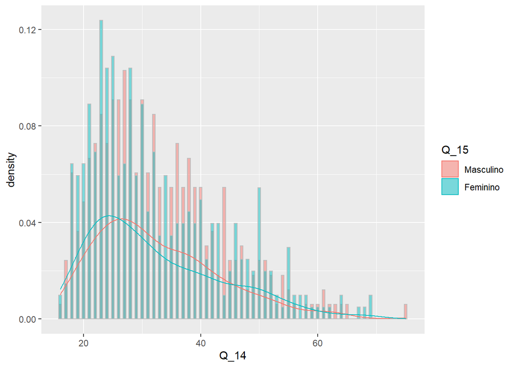

###Contando o número de casos por situação conjugal e a idade média dos entrevistados em imóveis alugados

| Situação Conjugal | Média de Idade | Número de Casos |
| --- | --- | --- |
| Solteiro(a) | 31.6 | 352 |
| Casado(a) | 32.3 | 287 |
| União consensual | 32.7 | 70 |
| Separado (a) | 55.7 | 3 |
| Divorciado(a)/desquitado(a) | 47.1 | 12 |
| Viúvo(a) | 53.1 | 10 |

### Numero de entrevistados por origem

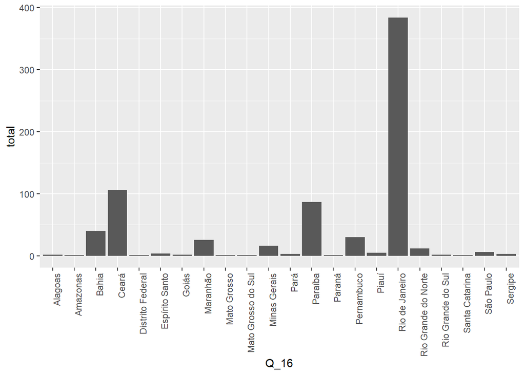

### Nível de escolaridade por Bairro

|  | Creche | Pré-escolar (maternal e jardim de infância) | Classe de alfabetização - ca | Alfabetização de jovens e adultos | Regular do ensino fundamental | Educação de jovens e adultos - eja - ou supletivo do ensino | Regular do ensino médio | Educação de jovens e adultos - eja - ou supletivo do ensino _duplicated_8 | Superior de graduação | Especialização de nível superior (mínimo de 360 horas) | Mestrado | Doutorado |
| --- | --- | --- | --- | --- | --- | --- | --- | --- | --- | --- | --- | --- |
| Borel/Tijuca | 0 | 0 | 2 | 11 | 27 | 0 | 31 | 1 | 3 | 0 | 1 | 0 |
| Campinho/Cascadura | 0 | 0 | 3 | 2 | 31 | 6 | 21 | 1 | 1 | 0 | 0 | 0 |
| Grotão/Penha | 0 | 2 | 7 | 11 | 25 | 13 | 18 | 1 | 2 | 0 | 0 | 0 |
| Jacaré/Maria da Graça | 1 | 2 | 1 | 17 | 27 | 6 | 43 | 10 | 2 | 0 | 0 | 0 |
| Parque Acari/Acari | 0 | 0 | 0 | 2 | 43 | 0 | 21 | 0 | 1 | 0 | 0 | 0 |
| Vila Rica de Irajá/Acari | 0 | 0 | 0 | 2 | 15 | 0 | 20 | 0 | 0 | 0 | 0 | 0 |
| Pavão Pavãozinho/Copacabana | 2 | 0 | 8 | 12 | 21 | 12 | 45 | 2 | 0 | 0 | 0 | 0 |
| Tijuquinha/Itanhangá | 0 | 0 | 1 | 8 | 29 | 0 | 55 | 0 | 5 | 0 | 0 | 0 |
| Parque Royal/Portuguesa - Ilha | 1 | 0 | 7 | 12 | 31 | 5 | 44 | 1 | 0 | 0 | 0 | 0 |

###Quantos trabalhos possui

|  | Um | Dois ou mais | Não trabalha |
| --- | --- | --- | --- |
| Borel/Tijuca | 54 | 4 | 18 |
| Campinho/Cascadura | 38 | 1 | 26 |
| Grotão/Penha | 48 | 0 | 31 |
| Jacaré/Maria da Graça | 68 | 6 | 35 |
| Parque Acari/Acari | 37 | 0 | 30 |
| Vila Rica de Irajá/Acari | 19 | 0 | 18 |
| Pavão Pavãozinho/Copacabana | 84 | 0 | 18 |
| Tijuquinha/Itanhangá | 71 | 6 | 21 |
| Parque Royal/Portuguesa - Ilha | 64 | 5 | 32 |

### Qual tipo de trabalho

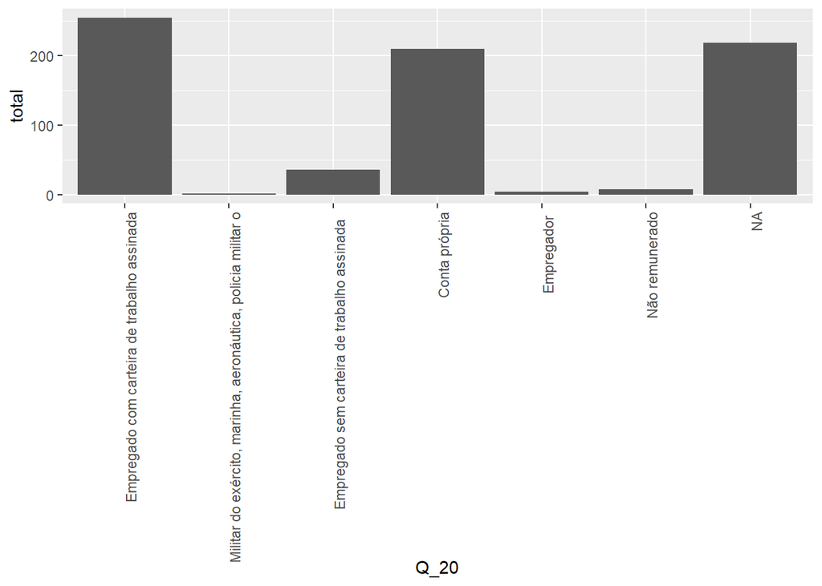

###qual setor trabalha

|  | Comércio | Serviço | Indústria | Construção civil | Outros |
| --- | --- | --- | --- | --- | --- |
| Borel/Tijuca | 22 | 28 | 1 | 3 | 4 |
| Campinho/Cascadura | 18 | 17 | 1 | 2 | 1 |
| Grotão/Penha | 24 | 21 | 2 | 1 | 0 |
| Jacaré/Maria da Graça | 40 | 24 | 5 | 4 | 5 |
| Parque Acari/Acari | 21 | 12 | 1 | 3 | 6 |
| Vila Rica de Irajá/Acari | 16 | 2 | 1 | 0 | 0 |
| Pavão Pavãozinho/Copacabana | 42 | 38 | 1 | 2 | 1 |
| Tijuquinha/Itanhangá | 40 | 30 | 2 | 5 | 0 |
| Parque Royal/Portuguesa - Ilha | 21 | 36 | 1 | 8 | 3 |

### Onde selocliza o trbalho

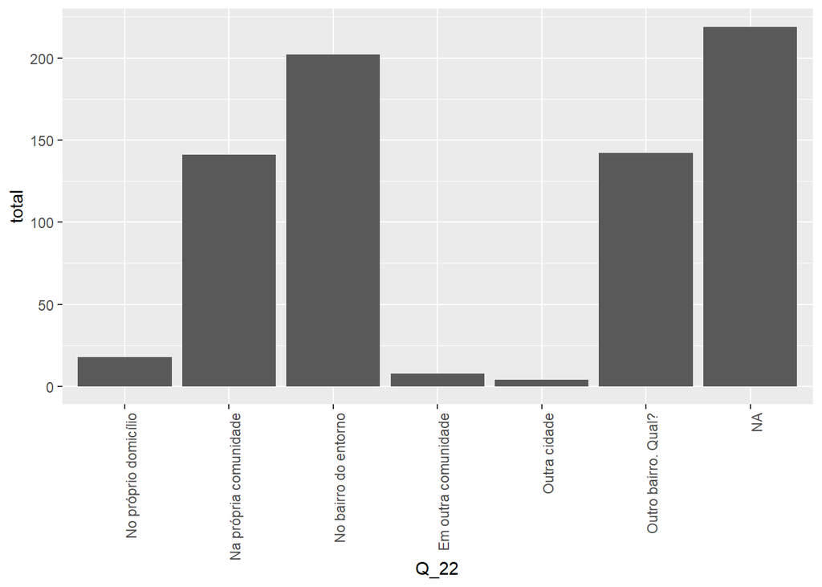

### Onde se localiza o trabalho

|  | No próprio domicílio | Na própria comunidade | No bairro do entorno | Em outra comunidade | Outra cidade | Outro bairro. Qual? |
| --- | --- | --- | --- | --- | --- | --- |
| Borel/Tijuca | 2 | 21 | 8 | 1 | 0 | 26 |
| Campinho/Cascadura | 4 | 8 | 12 | 1 | 0 | 14 |
| Grotão/Penha | 0 | 13 | 30 | 0 | 1 | 4 |
| Jacaré/Maria da Graça | 7 | 23 | 16 | 1 | 1 | 30 |
| Parque Acari/Acari | 1 | 17 | 10 | 1 | 1 | 13 |
| Vila Rica de Irajá/Acari | 0 | 9 | 7 | 0 | 0 | 3 |
| Pavão Pavãozinho/Copacabana | 2 | 17 | 41 | 1 | 0 | 23 |
| Tijuquinha/Itanhangá | 1 | 21 | 31 | 2 | 1 | 21 |
| Parque Royal/Portuguesa - Ilha | 1 | 12 | 47 | 1 | 0 | 8 |

### Qual sua renda pessoal mensal

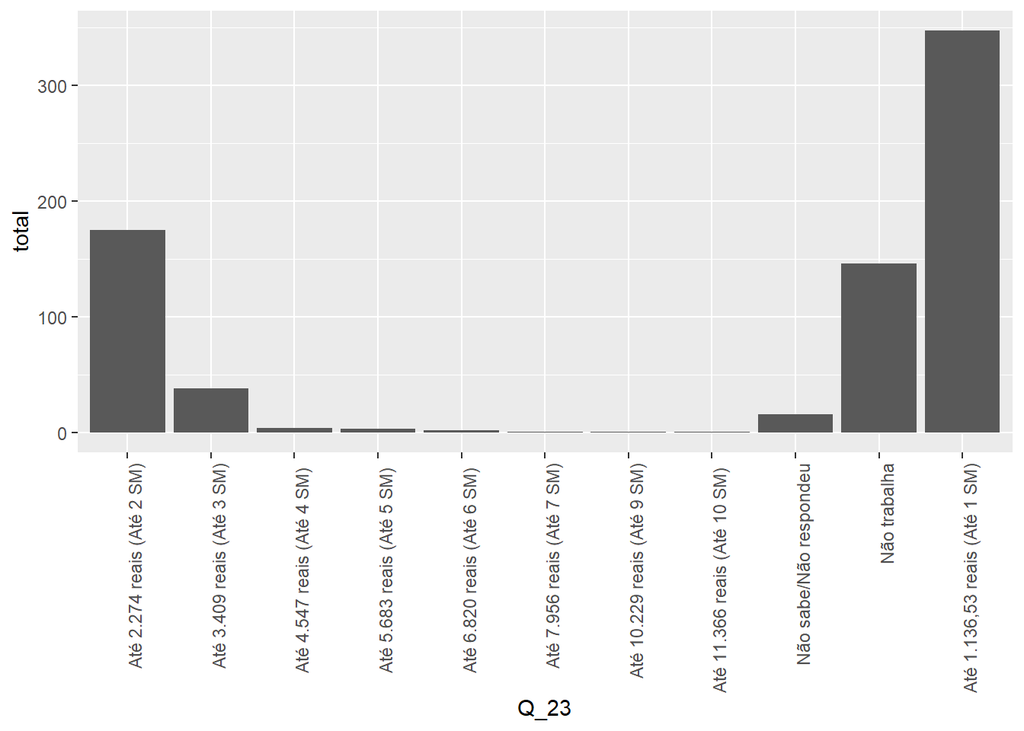

### Renda pessoal por comunidade

|  | Até 2.274 reais (Até 2 SM) | Até 3.409 reais (Até 3 SM) | Até 4.547 reais (Até 4 SM) | Até 5.683 reais (Até 5 SM) | Até 6.820 reais (Até 6 SM) | Até 7.956 reais (Até 7 SM) | Até 9.093 reais (Até 8 SM) | Até 10.229 reais (Até 9 SM) | Até 11.366 reais (Até 10 SM) | Até 17.047 reais (Até 15 SM) | Até 22.730 reais (Até 20 SM) | Mais de 22.730 reais (Mais de 20 SM) | Não sabe/Não respondeu | Não trabalha | Até 1.136,53 reais (Até 1 SM) |
| --- | --- | --- | --- | --- | --- | --- | --- | --- | --- | --- | --- | --- | --- | --- | --- |
| Borel/Tijuca | 21 | 10 | 1 | 1 | 0 | 0 | 0 | 0 | 0 | 0 | 0 | 0 | 2 | 9 | 32 |
| Campinho/Cascadura | 13 | 1 | 0 | 0 | 0 | 0 | 0 | 0 | 0 | 0 | 0 | 0 | 8 | 18 | 25 |
| Grotão/Penha | 13 | 1 | 0 | 0 | 0 | 0 | 0 | 0 | 0 | 0 | 0 | 0 | 0 | 29 | 36 |
| Jacaré/Maria da Graça | 16 | 4 | 0 | 0 | 0 | 0 | 0 | 0 | 0 | 0 | 0 | 0 | 2 | 18 | 69 |
| Parque Acari/Acari | 12 | 2 | 0 | 1 | 1 | 0 | 0 | 0 | 0 | 0 | 0 | 0 | 0 | 17 | 34 |
| Vila Rica de Irajá/Acari | 7 | 2 | 0 | 0 | 0 | 0 | 0 | 0 | 0 | 0 | 0 | 0 | 0 | 7 | 21 |
| Pavão Pavãozinho/Copacabana | 28 | 2 | 0 | 0 | 0 | 0 | 0 | 0 | 0 | 0 | 0 | 0 | 1 | 18 | 53 |
| Tijuquinha/Itanhangá | 38 | 11 | 3 | 1 | 1 | 1 | 0 | 0 | 1 | 0 | 0 | 0 | 0 | 13 | 29 |
| Parque Royal/Portuguesa - Ilha | 27 | 5 | 0 | 0 | 0 | 0 | 0 | 1 | 0 | 0 | 0 | 0 | 3 | 17 | 48 |

### Quantas pessoas contribuem para a renda

|  | 0 | 1 | 2 | 3 | 4 | 5 | 10 |
| --- | --- | --- | --- | --- | --- | --- | --- |
| Borel/Tijuca | 0 | 41 | 33 | 2 | 0 | 0 | 0 |
| Campinho/Cascadura | 0 | 44 | 18 | 3 | 0 | 0 | 0 |
| Grotão/Penha | 0 | 42 | 32 | 5 | 0 | 0 | 0 |
| Jacaré/Maria da Graça | 4 | 62 | 34 | 7 | 1 | 1 | 0 |
| Parque Acari/Acari | 0 | 49 | 12 | 5 | 1 | 0 | 0 |
| Vila Rica de Irajá/Acari | 2 | 22 | 12 | 1 | 0 | 0 | 0 |
| Pavão Pavãozinho/Copacabana | 3 | 47 | 39 | 12 | 1 | 0 | 0 |
| Tijuquinha/Itanhangá | 0 | 46 | 41 | 10 | 1 | 0 | 0 |
| Parque Royal/Portuguesa - Ilha | 1 | 55 | 40 | 1 | 2 | 1 | 1 |

### Qual sua renda familiar mensal

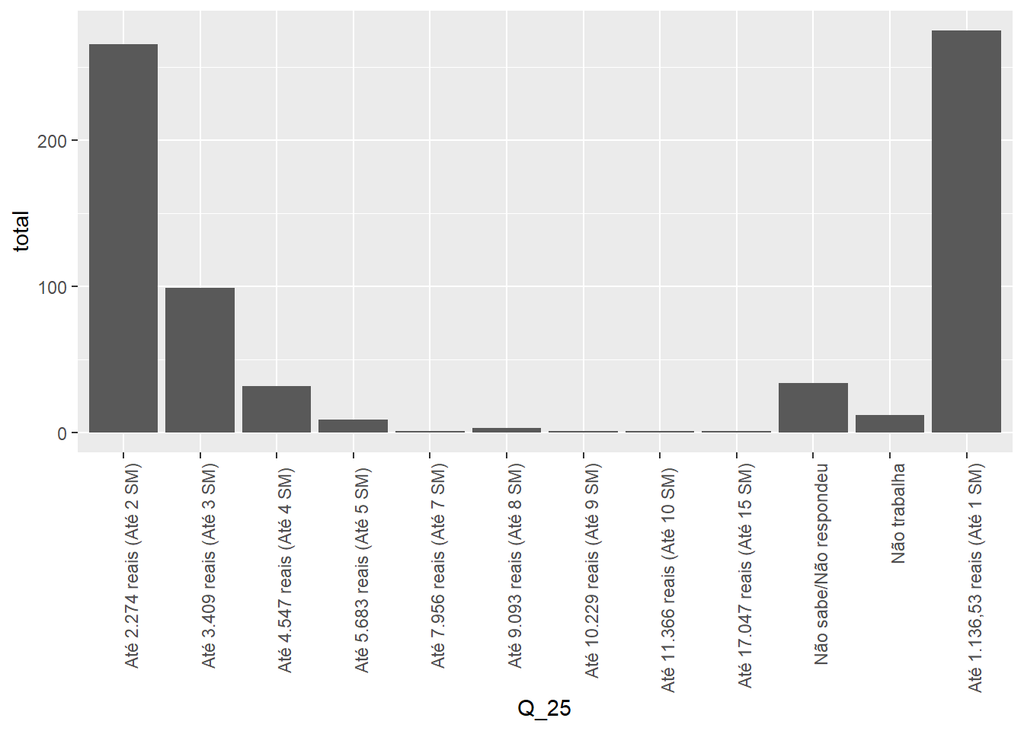

### Renda familiar por comunidade

|  | Até 2.274 reais (Até 2 SM) | Até 3.409 reais (Até 3 SM) | Até 4.547 reais (Até 4 SM) | Até 5.683 reais (Até 5 SM) | Até 6.820 reais (Até 6 SM) | Até 7.956 reais (Até 7 SM) | Até 9.093 reais (Até 8 SM) | Até 10.229 reais (Até 9 SM) | Até 11.366 reais (Até 10 SM) | Até 17.047 reais (Até 15 SM) | Até 22.730 reais (Até 20 SM) | Mais de 22.730 reais (Mais de 20 SM) | Não sabe/Não respondeu | Não trabalha | Até 1.136,53 reais (Até 1 SM) |
| --- | --- | --- | --- | --- | --- | --- | --- | --- | --- | --- | --- | --- | --- | --- | --- |
| Borel/Tijuca | 25 | 15 | 8 | 1 | 0 | 0 | 0 | 0 | 0 | 0 | 0 | 0 | 4 | 1 | 22 |
| Campinho/Cascadura | 23 | 8 | 2 | 0 | 0 | 0 | 0 | 0 | 0 | 0 | 0 | 0 | 11 | 1 | 20 |
| Grotão/Penha | 29 | 8 | 0 | 0 | 0 | 0 | 0 | 0 | 0 | 0 | 0 | 0 | 1 | 1 | 40 |
| Jacaré/Maria da Graça | 38 | 8 | 3 | 0 | 0 | 0 | 0 | 1 | 0 | 0 | 0 | 0 | 3 | 5 | 51 |
| Parque Acari/Acari | 19 | 5 | 0 | 2 | 0 | 0 | 2 | 0 | 0 | 0 | 0 | 0 | 3 | 0 | 36 |
| Vila Rica de Irajá/Acari | 10 | 3 | 2 | 0 | 0 | 0 | 0 | 0 | 0 | 0 | 0 | 0 | 3 | 1 | 18 |
| Pavão Pavãozinho/Copacabana | 38 | 18 | 5 | 0 | 0 | 0 | 0 | 0 | 0 | 0 | 0 | 0 | 3 | 3 | 35 |
| Tijuquinha/Itanhangá | 43 | 19 | 11 | 6 | 0 | 1 | 1 | 0 | 1 | 1 | 0 | 0 | 3 | 0 | 12 |
| Parque Royal/Portuguesa - Ilha | 41 | 15 | 1 | 0 | 0 | 0 | 0 | 0 | 0 | 0 | 0 | 0 | 3 | 0 | 41 |

### Numero de pessoas por domicilio

| Bairro | Média de pessoas por domicilio | Desvio Padrão |
| --- | --- | --- |
| Borel/Tijuca | 2.8 | 1.3 |
| Campinho/Cascadura | 2.9 | 1.1 |
| Grotão/Penha | 3.0 | 1.4 |
| Jacaré/Maria da Graça | 2.9 | 1.4 |
| Parque Acari/Acari | 3.5 | 1.9 |
| Vila Rica de Irajá/Acari | 3.0 | 1.3 |
| Pavão Pavãozinho/Copacabana | 3.0 | 1.3 |
| Tijuquinha/Itanhangá | 2.7 | 1.1 |
| Parque Royal/Portuguesa - Ilha | 2.9 | 1.6 |

# Análise do Mercado de aluguéis

### Este imóvel é:

|  | Próprio de algum morador, já pago | Próprio de algum morador, ainda pagando | Alugado | Cedido por empregador | Emprestado | Doação/herança | Outro |
| --- | --- | --- | --- | --- | --- | --- | --- |
| Borel/Tijuca | 2 | 0 | 74 | 0 | 0 | 0 | 0 |
| Campinho/Cascadura | 0 | 0 | 65 | 0 | 0 | 0 | 0 |
| Grotão/Penha | 0 | 0 | 79 | 0 | 0 | 0 | 0 |
| Jacaré/Maria da Graça | 0 | 1 | 108 | 0 | 0 | 0 | 0 |
| Parque Acari/Acari | 0 | 0 | 67 | 0 | 0 | 0 | 0 |
| Vila Rica de Irajá/Acari | 0 | 0 | 37 | 0 | 0 | 0 | 0 |
| Pavão Pavãozinho/Copacabana | 0 | 0 | 102 | 0 | 0 | 0 | 0 |
| Tijuquinha/Itanhangá | 0 | 0 | 98 | 0 | 0 | 0 | 0 |
| Parque Royal/Portuguesa - Ilha | 1 | 0 | 100 | 0 | 0 | 0 | 0 |

### Qual o valor pago pelo aluguel?

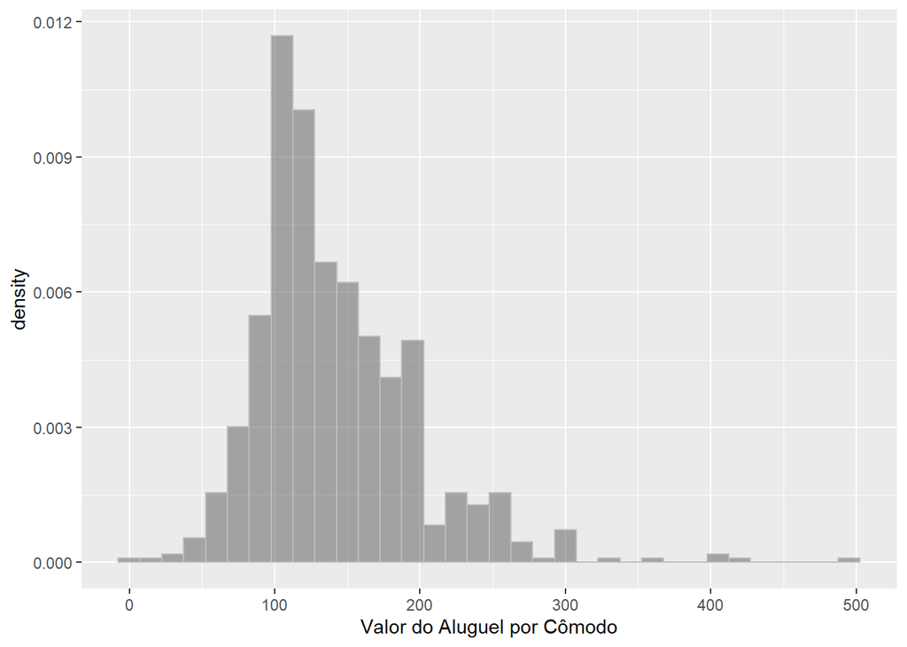

### Valor medio do aluguel por comodo

| Bairro | Valor médio do aluguel | Desvio Padrão |
| --- | --- | --- |
| Borel/Tijuca | 129.6 | 60.2 |
| Campinho/Cascadura | 115.1 | 35.8 |
| Grotão/Penha | 107.2 | 36.1 |
| Jacaré/Maria da Graça | 124.8 | 36.9 |
| Parque Acari/Acari | 116.1 | 50.7 |
| Vila Rica de Irajá/Acari | 121.8 | 42.6 |
| Pavão Pavãozinho/Copacabana | 173.6 | 47.9 |
| Tijuquinha/Itanhangá | 190.1 | 61.1 |
| Parque Royal/Portuguesa - Ilha | 160.6 | 47.9 |

### Onde alugou?

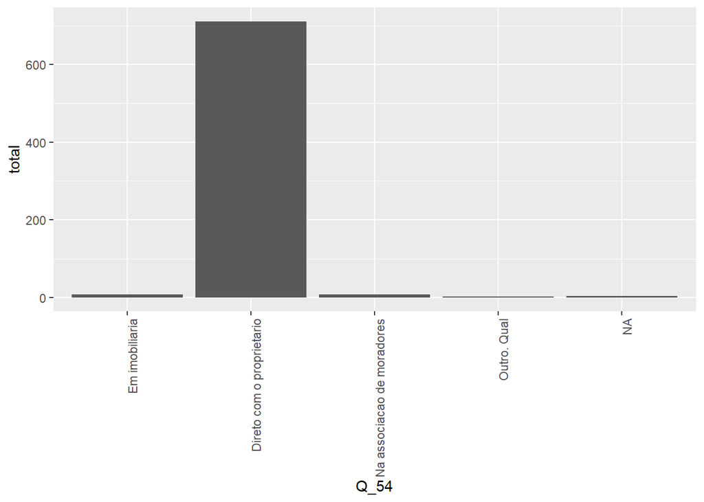

|  | Em imobiliaria | Direto com o proprietario | Na associacao de moradores | Outro. Qual |
| --- | --- | --- | --- | --- |
| Borel/Tijuca | 0 | 74 | 0 | 0 |
| Campinho/Cascadura | 1 | 64 | 0 | 0 |
| Grotão/Penha | 0 | 78 | 1 | 0 |
| Jacaré/Maria da Graça | 2 | 100 | 6 | 0 |
| Parque Acari/Acari | 1 | 65 | 0 | 1 |
| Vila Rica de Irajá/Acari | 0 | 37 | 0 | 0 |
| Pavão Pavãozinho/Copacabana | 0 | 101 | 1 | 0 |
| Tijuquinha/Itanhangá | 4 | 92 | 0 | 2 |
| Parque Royal/Portuguesa - Ilha | 0 | 100 | 0 | 0 |

### Tipo de contrato

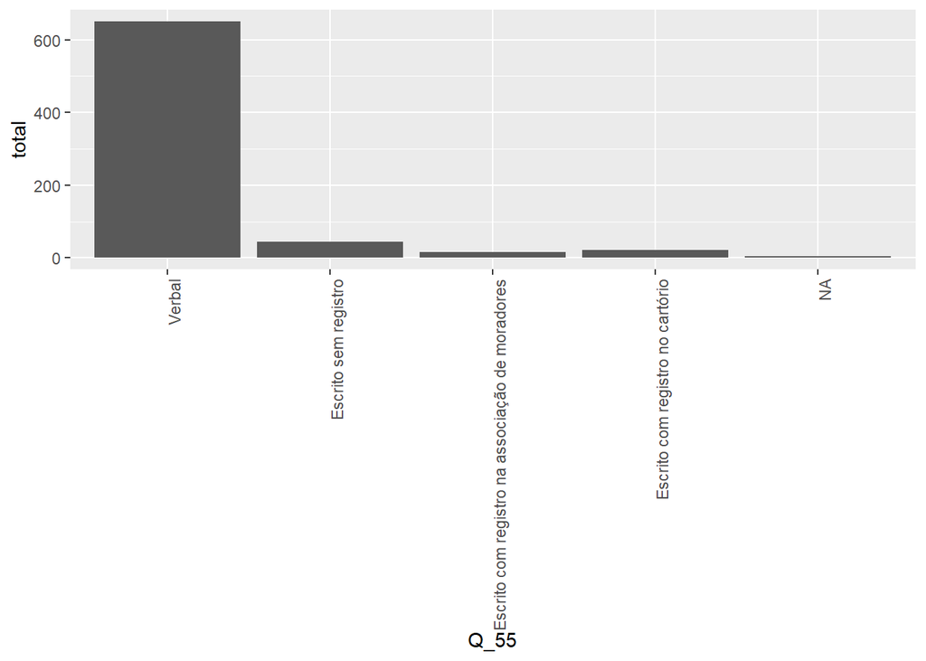

|  | Verbal | Escrito sem registro | Escrito com registro na associação de moradores | Escrito com registro no cartório | Escrito com registro em outro local. Qual? |
| --- | --- | --- | --- | --- | --- |
| Borel/Tijuca | 65 | 4 | 2 | 3 | 0 |
| Campinho/Cascadura | 59 | 0 | 0 | 6 | 0 |
| Grotão/Penha | 63 | 14 | 2 | 0 | 0 |
| Jacaré/Maria da Graça | 93 | 5 | 6 | 4 | 0 |
| Parque Acari/Acari | 63 | 2 | 0 | 2 | 0 |
| Vila Rica de Irajá/Acari | 33 | 3 | 0 | 1 | 0 |
| Pavão Pavãozinho/Copacabana | 92 | 9 | 1 | 0 | 0 |
| Tijuquinha/Itanhangá | 84 | 6 | 3 | 5 | 0 |
| Parque Royal/Portuguesa - Ilha | 98 | 1 | 1 | 0 | 0 |

### Quem recebe o aluguel?

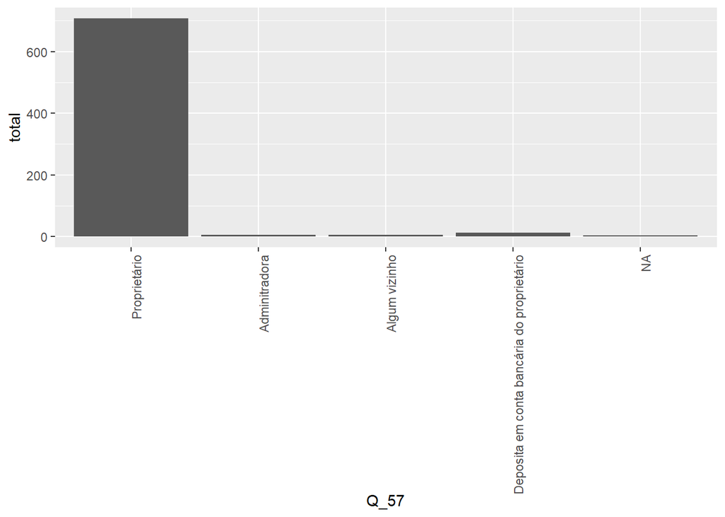

|  | Proprietário | Adminitradora | Algum vizinho | Deposita em conta bancária do proprietário |
| --- | --- | --- | --- | --- |
| Borel/Tijuca | 73 | 0 | 1 | 0 |
| Campinho/Cascadura | 63 | 1 | 1 | 0 |
| Grotão/Penha | 79 | 0 | 0 | 0 |
| Jacaré/Maria da Graça | 102 | 1 | 0 | 5 |
| Parque Acari/Acari | 65 | 0 | 1 | 1 |
| Vila Rica de Irajá/Acari | 37 | 0 | 0 | 0 |
| Pavão Pavãozinho/Copacabana | 102 | 0 | 0 | 0 |
| Tijuquinha/Itanhangá | 88 | 4 | 1 | 5 |
| Parque Royal/Portuguesa - Ilha | 98 | 0 | 1 | 1 |

### O proprietário tem outras casas alugadas?

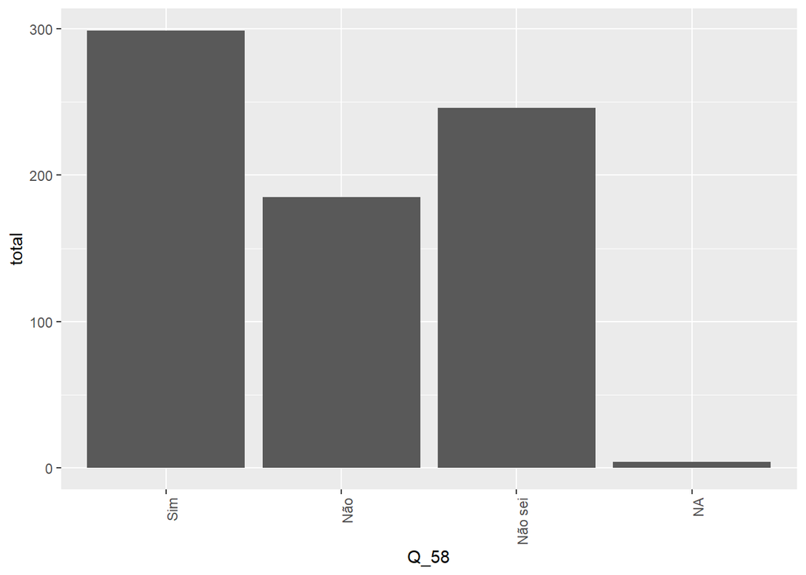

|  | Sim | Não | Não sei |
| --- | --- | --- | --- |
| Borel/Tijuca | 25 | 26 | 23 |
| Campinho/Cascadura | 18 | 29 | 18 |
| Grotão/Penha | 29 | 24 | 26 |
| Jacaré/Maria da Graça | 35 | 31 | 42 |
| Parque Acari/Acari | 32 | 18 | 17 |
| Vila Rica de Irajá/Acari | 17 | 9 | 11 |
| Pavão Pavãozinho/Copacabana | 43 | 12 | 47 |
| Tijuquinha/Itanhangá | 62 | 10 | 26 |
| Parque Royal/Portuguesa - Ilha | 38 | 26 | 36 |

### O pagamento é

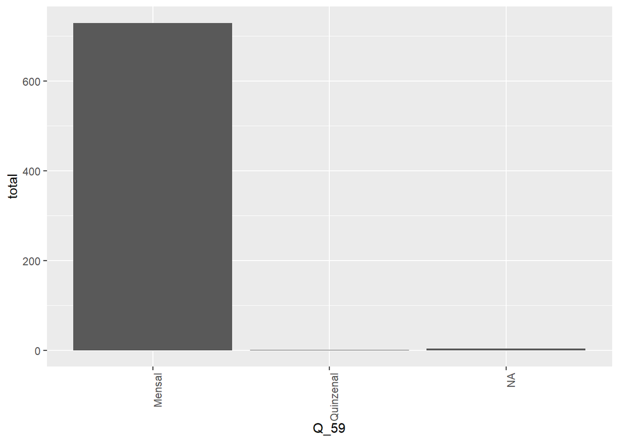

|  | Mensal | Quinzenal | Semanal | Outro |
| --- | --- | --- | --- | --- |
| Borel/Tijuca | 73 | 1 | 0 | 0 |
| Campinho/Cascadura | 65 | 0 | 0 | 0 |
| Grotão/Penha | 79 | 0 | 0 | 0 |
| Jacaré/Maria da Graça | 108 | 0 | 0 | 0 |
| Parque Acari/Acari | 67 | 0 | 0 | 0 |
| Vila Rica de Irajá/Acari | 37 | 0 | 0 | 0 |
| Pavão Pavãozinho/Copacabana | 102 | 0 | 0 | 0 |
| Tijuquinha/Itanhangá | 98 | 0 | 0 | 0 |
| Parque Royal/Portuguesa - Ilha | 100 | 0 | 0 | 0 |

### O reajuste é

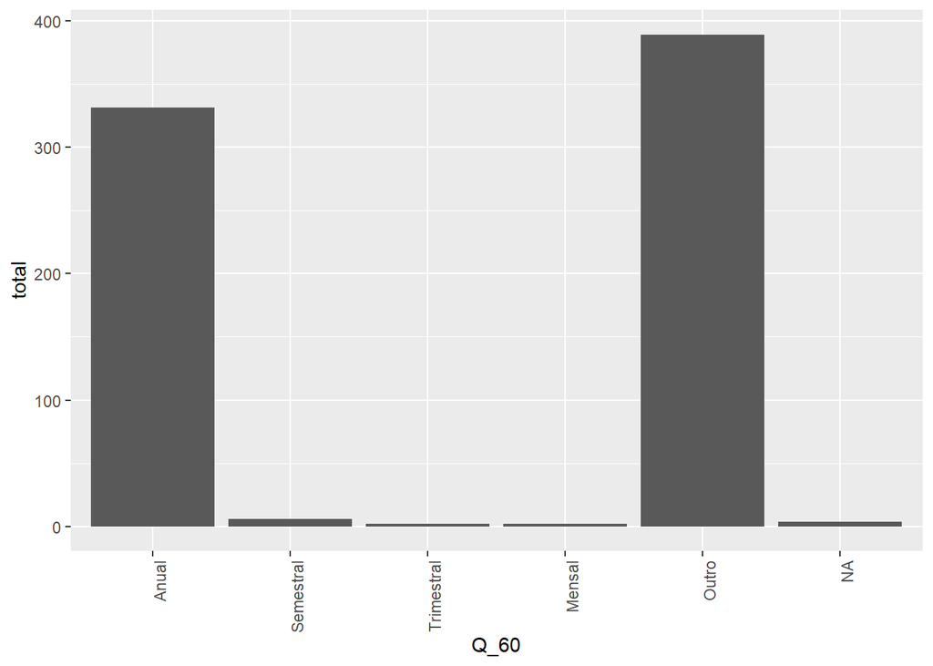

|  | Anual | Semestral | Trimestral | Mensal | Outro |
| --- | --- | --- | --- | --- | --- |
| Borel/Tijuca | 13 | 0 | 1 | 0 | 60 |
| Campinho/Cascadura | 36 | 0 | 0 | 0 | 29 |
| Grotão/Penha | 61 | 0 | 0 | 0 | 18 |
| Jacaré/Maria da Graça | 44 | 1 | 0 | 1 | 62 |
| Parque Acari/Acari | 16 | 0 | 0 | 0 | 51 |
| Vila Rica de Irajá/Acari | 8 | 0 | 0 | 0 | 29 |
| Pavão Pavãozinho/Copacabana | 55 | 0 | 0 | 0 | 47 |
| Tijuquinha/Itanhangá | 49 | 2 | 0 | 0 | 47 |
| Parque Royal/Portuguesa - Ilha | 49 | 3 | 1 | 1 | 46 |

### Pretende comprar imovel na comunidade?

|  | Sim | Não |
| --- | --- | --- |
| Borel/Tijuca | 42 | 34 |
| Campinho/Cascadura | 14 | 51 |
| Grotão/Penha | 29 | 50 |
| Jacaré/Maria da Graça | 40 | 69 |
| Parque Acari/Acari | 33 | 34 |
| Vila Rica de Irajá/Acari | 14 | 23 |
| Pavão Pavãozinho/Copacabana | 40 | 62 |
| Tijuquinha/Itanhangá | 63 | 35 |
| Parque Royal/Portuguesa - Ilha | 48 | 53 |

###Acredita que os imóveis da comunidade valem mais ou menos que os do entorno?

|  | Mais | Menos | Igual | Não sabe |
| --- | --- | --- | --- | --- |
| Borel/Tijuca | 8 | 23 | 7 | 4 |
| Campinho/Cascadura | 5 | 6 | 1 | 2 |
| Grotão/Penha | 10 | 17 | 2 | 0 |
| Jacaré/Maria da Graça | 8 | 26 | 5 | 1 |
| Parque Acari/Acari | 8 | 20 | 2 | 3 |
| Vila Rica de Irajá/Acari | 4 | 5 | 4 | 1 |
| Pavão Pavãozinho/Copacabana | 6 | 32 | 0 | 2 |
| Tijuquinha/Itanhangá | 28 | 21 | 9 | 5 |
| Parque Royal/Portuguesa - Ilha | 15 | 30 | 1 | 2 |

###Na sua opinião, qual a área mais valorizada da cidade?

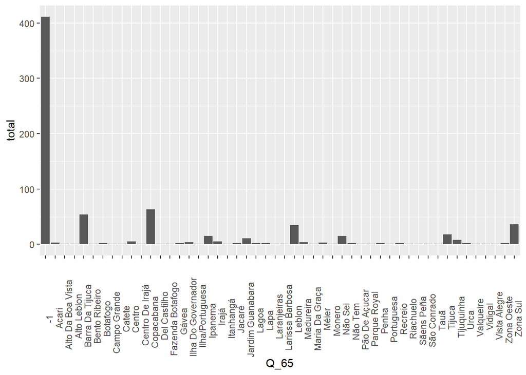

###Na sua opinião, qual a área menos valorizada da cidade?

[figure not shown]

[output not shown]

###Valor no momento da aquisição

| Bairro | Valor médio na hora da aquisição | Desvio Padrão |
| --- | --- | --- |
| Borel/Tijuca | 5284.0 | 4659.3 |
| Campinho/Cascadura | 5722.5 | 6382.4 |
| Grotão/Penha | 7621.5 | 5963.6 |
| Jacaré/Maria da Graça | 5435.9 | 4852.4 |
| Parque Acari/Acari | 7916.7 | 4559.8 |
| Vila Rica de Irajá/Acari | 7430.6 | 2477.9 |
| Pavão Pavãozinho/Copacabana | 10175.0 | 11938.7 |
| Tijuquinha/Itanhangá | 24057.7 | 10535.7 |
| Parque Royal/Portuguesa - Ilha | 10173.8 | 4468.5 |

###Valor atual aproximado

[output not shown]

###Registrou a transação

|  | Cartório de registro de imóveis | Associação de moradores | Outro | Não |
| --- | --- | --- | --- | --- |
| Borel/Tijuca | 3 | 15 | 0 | 17 |
| Campinho/Cascadura | 6 | 7 | 0 | 5 |
| Grotão/Penha | 1 | 14 | 0 | 9 |
| Jacaré/Maria da Graça | 2 | 15 | 0 | 6 |
| Parque Acari/Acari | 1 | 4 | 0 | 9 |
| Vila Rica de Irajá/Acari | 0 | 1 | 0 | 5 |
| Pavão Pavãozinho/Copacabana | 3 | 14 | 0 | 1 |
| Tijuquinha/Itanhangá | 5 | 7 | 0 | 1 |
| Parque Royal/Portuguesa - Ilha | 1 | 10 | 0 | 3 |

###Pagou taxa pela transação

|  | Não | Sim, na associação de moradores | Sim, na prefeitura | Sim, no cartório de registro de imóveis |
| --- | --- | --- | --- | --- |
| Borel/Tijuca | 25 | 9 | 0 | 1 |
| Campinho/Cascadura | 7 | 7 | 1 | 3 |
| Grotão/Penha | 9 | 15 | 0 | 0 |
| Jacaré/Maria da Graça | 9 | 11 | 0 | 3 |
| Parque Acari/Acari | 8 | 4 | 0 | 2 |
| Vila Rica de Irajá/Acari | 6 | 0 | 0 | 0 |
| Pavão Pavãozinho/Copacabana | 1 | 16 | 0 | 1 |
| Tijuquinha/Itanhangá | 2 | 6 | 0 | 5 |
| Parque Royal/Portuguesa - Ilha | 3 | 10 | 1 | 0 |

###Como obteve informação sobre o imóvel

|  | Jornal | Porta a porta | Amigos / parentes | Associação de moradores | Corretor | Outros |
| --- | --- | --- | --- | --- | --- | --- |
| Borel/Tijuca | 0 | 4 | 20 | 1 | 0 | 10 |
| Campinho/Cascadura | 0 | 1 | 15 | 0 | 0 | 2 |
| Grotão/Penha | 1 | 5 | 16 | 2 | 0 | 0 |
| Jacaré/Maria da Graça | 0 | 1 | 17 | 2 | 1 | 2 |
| Parque Acari/Acari | 0 | 1 | 9 | 0 | 0 | 4 |
| Vila Rica de Irajá/Acari | 0 | 1 | 5 | 0 | 0 | 0 |
| Pavão Pavãozinho/Copacabana | 0 | 0 | 13 | 2 | 0 | 3 |
| Tijuquinha/Itanhangá | 0 | 1 | 9 | 0 | 1 | 2 |
| Parque Royal/Portuguesa - Ilha | 0 | 3 | 9 | 1 | 0 | 1 |

###Acha que se ganhar o titulo de propriedade valorizara o imovel

|  | Sim | Não |
| --- | --- | --- |
| Borel/Tijuca | 30 | 5 |
| Campinho/Cascadura | 15 | 3 |
| Grotão/Penha | 21 | 3 |
| Jacaré/Maria da Graça | 18 | 5 |
| Parque Acari/Acari | 11 | 3 |
| Vila Rica de Irajá/Acari | 5 | 1 |
| Pavão Pavãozinho/Copacabana | 17 | 1 |
| Tijuquinha/Itanhangá | 10 | 3 |
| Parque Royal/Portuguesa - Ilha | 13 | 1 |

| Bairros | Número de Questionários venda |
| --- | --- |
| Borel/Tijuca | 29 |
| Campinho/Cascadura | 18 |
| Grotão/Penha | 70 |
| Jacaré/Maria da Graça | 24 |
| Parque Acari/Acari | 28 |
| Vila Rica de Irajá/Acari | 9 |
| Pavão Pavãozinho/Copacabana | 16 |
| Tijuquinha/Itanhangá | 7 |
| Parque Royal/Portuguesa - Ilha | 36 |

###Quanto esta vendendo (reais/comodo)

| Bairro | Valor médio | Desvio Padrão |
| --- | --- | --- |
| Borel/Tijuca | 14469.2 | 8435.4 |
| Campinho/Cascadura | 11639.6 | 10213.6 |
| Grotão/Penha | 11587.9 | 4964.9 |
| Jacaré/Maria da Graça | 12443.5 | 7318.3 |
| Parque Acari/Acari | 14902.6 | 8282.0 |
| Vila Rica de Irajá/Acari | 12811.9 | 5753.2 |
| Pavão Pavãozinho/Copacabana | 24755.2 | 14603.4 |
| Tijuquinha/Itanhangá | 35250.0 | 32847.8 |
| Parque Royal/Portuguesa - Ilha | 19244.6 | 9739.9 |

###Em que baseou o preço

|  | Nos preços dos imóveis praticados na rua em que você mora | Nos preços dos imóveis do entorno da sua comunidade (mesmo b | Nos preços dos imóveis em outras comunidades. Quais? | Nos preços que a associação de moradores fixou | Nos gastos realizados na construção/reforma do domicílio | Outros |
| --- | --- | --- | --- | --- | --- | --- |
| Borel/Tijuca | 14 | 4 | 0 | 0 | 8 | 3 |
| Campinho/Cascadura | 8 | 1 | 1 | 0 | 7 | 1 |
| Grotão/Penha | 41 | 13 | 1 | 3 | 12 | 0 |
| Jacaré/Maria da Graça | 15 | 2 | 0 | 1 | 3 | 3 |
| Parque Acari/Acari | 11 | 2 | 0 | 0 | 13 | 2 |
| Vila Rica de Irajá/Acari | 4 | 2 | 0 | 0 | 3 | 0 |
| Pavão Pavãozinho/Copacabana | 11 | 1 | 0 | 0 | 4 | 0 |
| Tijuquinha/Itanhangá | 2 | 1 | 1 | 1 | 0 | 2 |
| Parque Royal/Portuguesa - Ilha | 21 | 3 | 1 | 2 | 7 | 2 |

###Há quanto tempo está a venda (anos)

|  | 0 | 1 | 2 | 3 | 4 | 5 | 6 | 8 | 10 | 12 | 18 | 25 | 70 |
| --- | --- | --- | --- | --- | --- | --- | --- | --- | --- | --- | --- | --- | --- |
| Borel/Tijuca | 12 | 7 | 5 | 2 | 0 | 2 | 1 | 0 | 0 | 0 | 0 | 0 | 0 |
| Campinho/Cascadura | 7 | 5 | 2 | 1 | 1 | 0 | 0 | 0 | 0 | 0 | 2 | 0 | 0 |
| Grotão/Penha | 60 | 4 | 0 | 0 | 1 | 2 | 0 | 1 | 0 | 1 | 0 | 1 | 0 |
| Jacaré/Maria da Graça | 16 | 6 | 1 | 0 | 0 | 0 | 0 | 0 | 0 | 0 | 0 | 0 | 1 |
| Parque Acari/Acari | 21 | 2 | 3 | 0 | 1 | 1 | 0 | 0 | 0 | 0 | 0 | 0 | 0 |
| Vila Rica de Irajá/Acari | 5 | 2 | 0 | 1 | 0 | 0 | 0 | 1 | 0 | 0 | 0 | 0 | 0 |
| Pavão Pavãozinho/Copacabana | 12 | 2 | 1 | 1 | 0 | 0 | 0 | 0 | 0 | 0 | 0 | 0 | 0 |
| Tijuquinha/Itanhangá | 4 | 1 | 1 | 0 | 0 | 1 | 0 | 0 | 0 | 0 | 0 | 0 | 0 |
| Parque Royal/Portuguesa - Ilha | 24 | 6 | 3 | 0 | 1 | 0 | 0 | 1 | 1 | 0 | 0 | 0 | 0 |

###Colocou anuncio

|  | Em jornais | Na associação de moradores | Em imobiliárias | Placas | Em estabelecimento comercial na região | Não colocou anúncio |
| --- | --- | --- | --- | --- | --- | --- |
| Borel/Tijuca | 1 | 4 | 0 | 3 | 0 | 21 |
| Campinho/Cascadura | 0 | 0 | 0 | 3 | 0 | 15 |
| Grotão/Penha | 3 | 23 | 0 | 2 | 0 | 42 |
| Jacaré/Maria da Graça | 1 | 3 | 0 | 4 | 1 | 15 |
| Parque Acari/Acari | 0 | 1 | 0 | 11 | 0 | 16 |
| Vila Rica de Irajá/Acari | 0 | 0 | 0 | 5 | 0 | 4 |
| Pavão Pavãozinho/Copacabana | 0 | 0 | 0 | 1 | 0 | 15 |
| Tijuquinha/Itanhangá | 0 | 0 | 1 | 1 | 0 | 5 |
| Parque Royal/Portuguesa - Ilha | 0 | 1 | 0 | 15 | 1 | 19 |

###Gostaria de mudar de casa

|  | Para outra casa dentro da comunidade | Para outra comunidade | Para outro bairro no asfalto. Qual? | Outra | Não |
| --- | --- | --- | --- | --- | --- |
| Borel/Tijuca | 5 | 0 | 16 | 5 | 3 |
| Campinho/Cascadura | 3 | 2 | 8 | 2 | 3 |
| Grotão/Penha | 25 | 11 | 27 | 5 | 2 |
| Jacaré/Maria da Graça | 3 | 4 | 9 | 4 | 4 |
| Parque Acari/Acari | 6 | 0 | 15 | 2 | 5 |
| Vila Rica de Irajá/Acari | 3 | 0 | 6 | 0 | 0 |
| Pavão Pavãozinho/Copacabana | 4 | 1 | 4 | 5 | 2 |
| Tijuquinha/Itanhangá | 2 | 2 | 1 | 1 | 1 |
| Parque Royal/Portuguesa - Ilha | 8 | 2 | 14 | 9 | 3 |

###Motivos para a saida da comunidade

|  | Distancia do trabalho | Fugir da violência | Sair do aluguel | Inexistência de programa de urbanização | Falta de transporte | Voltar para a cidade de origem | Casamento | Tem hoje melhor renda/posição social | Tamanho do domicílio | Precariedade do serviço/comércio | Distância dos amigos | Distância dos parentes | Desvalorização do domicílio | Não gosta do bairro | Inexistência de escola/posto de saúde | Inexistência de programa de regularização | Outro |
| --- | --- | --- | --- | --- | --- | --- | --- | --- | --- | --- | --- | --- | --- | --- | --- | --- | --- |
| Borel/Tijuca | 2 | 13 | 0 | 0 | 0 | 0 | 0 | 4 | 0 | 1 | 0 | 1 | 0 | 0 | 0 | 0 | 5 |
| Campinho/Cascadura | 0 | 6 | 0 | 0 | 0 | 1 | 0 | 0 | 0 | 0 | 2 | 2 | 0 | 1 | 0 | 0 | 3 |
| Grotão/Penha | 4 | 54 | 1 | 0 | 3 | 1 | 0 | 1 | 1 | 0 | 1 | 1 | 0 | 0 | 0 | 0 | 1 |
| Jacaré/Maria da Graça | 0 | 13 | 0 | 0 | 0 | 0 | 0 | 1 | 0 | 0 | 0 | 1 | 0 | 0 | 0 | 0 | 5 |
| Parque Acari/Acari | 0 | 6 | 0 | 0 | 0 | 1 | 0 | 1 | 1 | 0 | 0 | 4 | 2 | 0 | 0 | 0 | 8 |
| Vila Rica de Irajá/Acari | 0 | 2 | 0 | 0 | 0 | 0 | 0 | 0 | 2 | 0 | 0 | 3 | 0 | 0 | 0 | 0 | 2 |
| Pavão Pavãozinho/Copacabana | 0 | 5 | 0 | 1 | 0 | 0 | 0 | 3 | 0 | 0 | 0 | 0 | 0 | 0 | 0 | 0 | 5 |
| Tijuquinha/Itanhangá | 1 | 1 | 0 | 0 | 0 | 1 | 0 | 0 | 0 | 1 | 0 | 0 | 0 | 0 | 0 | 0 | 2 |
| Parque Royal/Portuguesa - Ilha | 0 | 4 | 2 | 1 | 0 | 1 | 1 | 1 | 4 | 0 | 0 | 5 | 2 | 3 | 0 | 0 | 9 |